# 情報処理応用演習: 期末課題

最終修正: 2020-08-30

## 1. `Countries_SES.csv`の処理と可視化

1. パッケージ`tidyverse`を読み込む。
2. `Countries_SES.csv`を読み込み、`SES_df`という名のオブジェクトで格納する。
   - `Country`: 国名
   - `Population`: 人口 (人)
   - `Area`: 面積（Km<sup>2</sup>）
   - `GDP`: 国内総生産（100万米ドル）
   - `Continent`: 大陸

```r
library(tidyverse)
SES_df <- read_csv("Data/Countries_SES.csv")
```

3. 人口密度を計算し、`Density`という名の新しい列に格納する。`Density`列は`Area`と`GDP`の間へ移動させる。

$$人口密度 = \frac{人口}{面積}.$$

```r
SES_df <- SES_df %>%
    mutate(Density = Population / Area) %>%
    relocate(Density, .after = Area)
```

4. 大陸ごとに何カ国のケースがあるかを表す棒グラフを作成する。

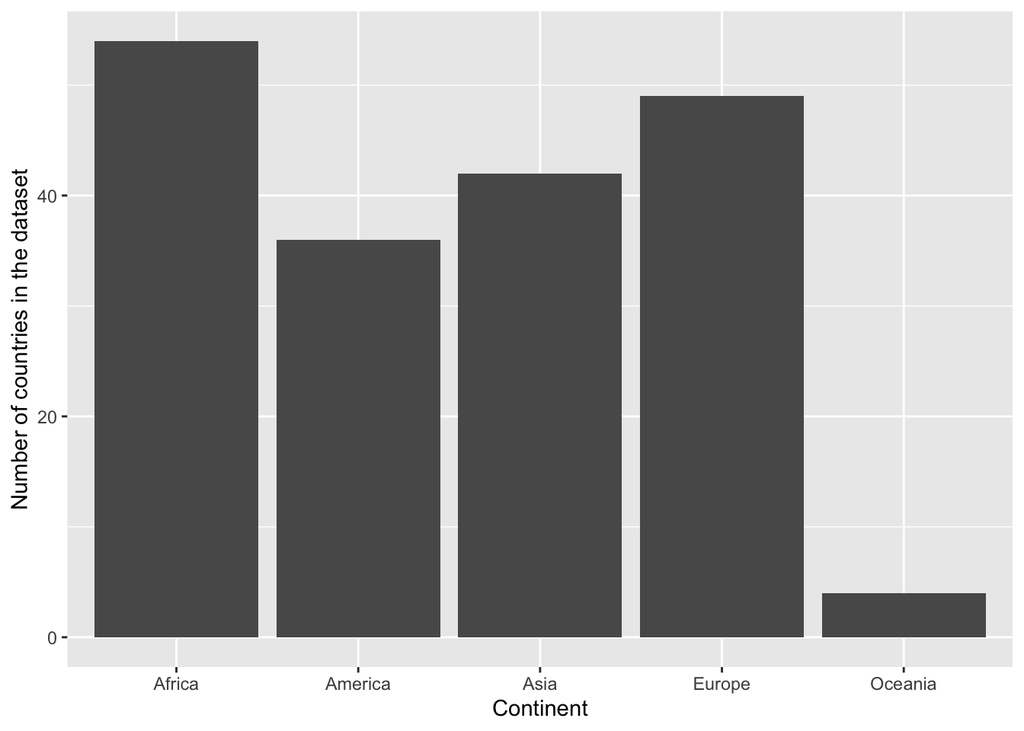

```r
SES_df %>%
    ggplot() +
    geom_bar(aes(x = Continent)) +
    labs(x = "Continent", y = "Number of countries in the dataset")
```

5. `table()`関数を使用し、`Continent`変数の度数を確認する。

```r
table(SES_df$Continent)
```

```
##
##  Africa America    Asia  Europe Oceania
##      54      36      42      49       4
```

6. 一人当たりGDPを計算し、`GDP_per_capita`という名の新しい列に格納する。`GDP_per_capita`は列は`GDP`と`Continent`列の間へ移動させる。
   - `GDP`の単位は100万ドルであることに注意

$$一人当たり\text{GDP} = \frac{\text{GDP} \times 1000000}{人口}.$$

```r
SES_df <- SES_df %>%
    mutate(GDP_per_capita = (GDP * 1000000 / Population) ) %>%
    relocate(GDP_per_capita, .after = GDP)
```

7. ここまでの処理を確認するために改めて`SES_df`を出力する。

```r
SES_df
```

```
## # A tibble: 185 x 7
##    Country           Population    Area Density     GDP GDP_per_capita Continent
##    <chr>                  <dbl>   <dbl>   <dbl>   <dbl>          <dbl> <chr>
##  1 Afghanistan         38928346  652860   59.6   1.91e4           491. Asia
##  2 Albania              2877797   27400  105.    1.53e4          5309. Europe
##  3 Algeria             43851044 2381740   18.4   1.70e5          3876. Africa
##  4 Andorra                77265     470  164.    3.15e3         40821. Europe
##  5 Angola              32866272 1246700   26.4   9.46e4          2879. Africa
##  6 Antigua and Barb…      97929     440  223.    1.73e3         17643. America
##  7 Argentina           45195774 2736690   16.5   4.50e5          9949. America
##  8 Armenia              2963243   28470  104.    1.37e4          4614. Europe
##  9 Australia           25499884 7682300    3.32  1.39e6         54615. Oceania
## 10 Austria              9006398   82409  109.    4.46e5         49555. Europe
## # … with 175 more rows
```

8. 一人当たりGDP (`GDP_per_capita`)の平均値とデータ内の国家数を大陸 (`Continet`)ごとに計算し、計算結果を`SES_Summary1`という名のオブジェクトとして格納する。国家数の列名は`N`、一人当たりGDPの平均値は`GDP_per_capita`とする。

```r
SES_Summary1 <- SES_df %>%
    group_by(Continent) %>%
    summarise(N              = n(),
              GDP_per_capita = mean(GDP_per_capita, na.rm = TRUE),
              .groups        = "drop")
```

9. `SES_Summary1`を出力する。

```r
SES_Summary1
```

```
## # A tibble: 5 x 3
##   Continent     N GDP_per_capita
##   <chr>     <int>          <dbl>
## 1 Africa       54          2514.
## 2 America      36         12527.
## 3 Asia         42         13168.
## 4 Europe       49         35575.
## 5 Oceania       4         26578.
```

10. `SES_Summary1`を用い、棒グラフを作成する。横軸は大陸名、縦軸は一人当たりGDPとする。
    - 横軸のラベルは「Continent」、縦軸のラベルは「Mean of GDP per capita (USD)」とする。

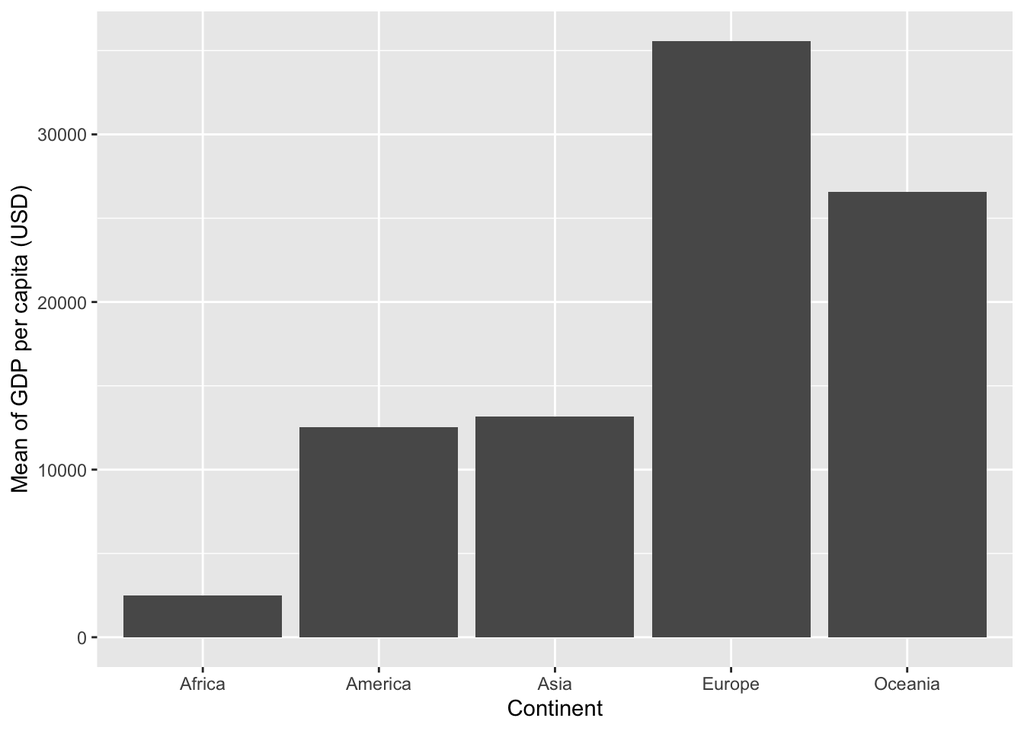

```r
SES_Summary1 %>%
    ggplot() +
    geom_bar(aes(x = Continent, y = GDP_per_capita), stat = "identity") +
    labs(x = "Continent", y = "Mean of GDP per capita (USD)")
```

## 2. `Countries_HDI.csv`の処理と可視化

1. `Countries_HDI.csv`ファイルを読み込み、`HDI_df`という名のオブジェクトに格納する。
   - `Ranking`: 人間開発指数ランキング
   - `Country`: 国名
   - `HDI`: 2018年人間開発指数
   - `Life_expectancy_at_birth`: 期待寿命
   - `Expected_yrs_of_schooling`: 期待教育年数
   - `Mean_yrs_of_schooling`: 平均教育年数
   - `GNI_per_capita`: 国民総所得（100万米ドル）

```r
HDI_df <- read_csv("Data/Countries_HDI.csv")
```

2. `SES_df`と`HDI_df`を結合し、`Country_df`という名のオブジェクトに格納する。キーは`Country`変数である。
   - `SES_df`には185カ国、`HDI_df`には179カ国のデータが入っている。`Country_df`は185カ国データになるようにすること。

```r
Country_df <- left_join(SES_df, HDI_df, by = "Country")
```

3. `Country_df`の変数名を出力する。

```r
names(Country_df)
```

```
##  [1] "Country"                   "Population"
##  [3] "Area"                      "Density"
##  [5] "GDP"                       "GDP_per_capita"
##  [7] "Continent"                 "Ranking"
##  [9] "HDI"                       "Life_expectancy_at_birth"
## [11] "Expected_yrs_of_schooling" "Mean_yrs_of_schooling"
## [13] "GNI_per_capita"
```

4. `Country_df`から`Mean_yrs_of_schooling`、`GIN_per_capita`変数を除外する。
5. `Expected_yrs_of_schooling`と`Life_expectancy_at_birth`の変数名をそれぞれ`Education`、`Life`に変更する。

```r
Country_df <- Country_df %>%
  select(Country:HDI, -Ranking,
         Life = Life_expectancy_at_birth,
         Education = Expected_yrs_of_schooling)
```

6. 修正済みの`Country_df`の中身を出力する。

```r
Country_df
```

```
## # A tibble: 185 x 10
##    Country Population   Area Density    GDP GDP_per_capita Continent   HDI  Life
##    <chr>        <dbl>  <dbl>   <dbl>  <dbl>          <dbl> <chr>     <dbl> <dbl>
##  1 Afghan…   38928346 6.53e5   59.6  1.91e4           491. Asia      0.496  64.5
##  2 Albania    2877797 2.74e4  105.   1.53e4          5309. Europe    0.791  78.5
##  3 Algeria   43851044 2.38e6   18.4  1.70e5          3876. Africa    0.759  76.7
##  4 Andorra      77265 4.70e2  164.   3.15e3         40821. Europe    0.857  81.8
##  5 Angola    32866272 1.25e6   26.4  9.46e4          2879. Africa    0.574  60.8
##  6 Antigu…      97929 4.40e2  223.   1.73e3         17643. America   0.776  76.9
##  7 Argent…   45195774 2.74e6   16.5  4.50e5          9949. America   0.83   76.5
##  8 Armenia    2963243 2.85e4  104.   1.37e4          4614. Europe    0.76   74.9
##  9 Austra…   25499884 7.68e6    3.32 1.39e6         54615. Oceania   0.938  83.3
## 10 Austria    9006398 8.24e4  109.   4.46e5         49555. Europe    0.914  81.4
## # … with 175 more rows, and 1 more variable: Education <dbl>
```

7. 期待教育年数の分布をヒストグラムで出力する。棒の枠線は白とする（`color = "white"`）。

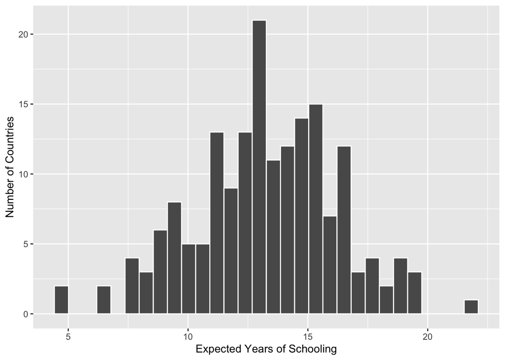

```r
Country_df %>%
  ggplot() +
  geom_histogram(aes(x = Education), color = "white") +
  labs(x = "Expected Years of Schooling", y = "Number of Countries")
```

8. 大陸ごとの期待寿命の箱ひげ図を作成する。`fill`マッピングを使用し、大陸ごとに異なる色を付けること。

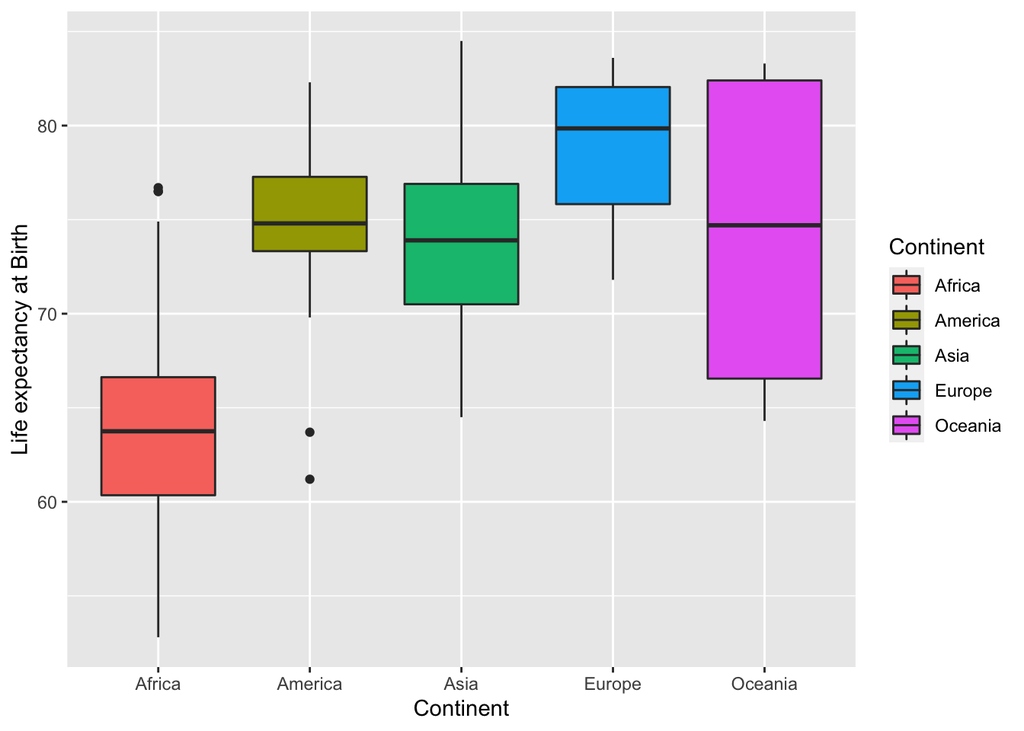

```r
Country_df %>%
  ggplot() +
  geom_boxplot(aes(x = Continent, y = Life, fill = Continent)) +
  labs(x = "Continent", y = "Life expectancy at Birth")
```

## 3. `Countries_Politics.csv`の処理と可視化

1. `Countries_Politics.csv`ファイルを読み込み、`Politics_df`という名のオブジェクトに格納する。
   - `Country`: 国名
   - `G7`: G7加盟有無 (0: No / 1: Yes)
   - `G20`: G29加盟有無 (0: No / 1: Yes)
   - `OECD`: OECD加盟有無 (0: No / 1: Yes)
   - `Freedom`: Freedom House指数（民主主義指標の1つ）

```r
Politics_df <- read_csv("Data/Countries_Politics.csv")
```

2. `G7`、`G20`、`OECD`列の数値を足し、`Developed`という名の列として追加する。

```r
Politics_df <- Politics_df %>%
  mutate(Developed = G7 + G20 + OECD)
```

3. `Politics_df`を出力し、`Developed`列が追加されたことを確認する。

```r
Politics_df
```

```
## # A tibble: 186 x 6
##    Country                G7   G20  OECD Freedom Developed
##    <chr>               <dbl> <dbl> <dbl>   <dbl>     <dbl>
##  1 Afghanistan             0     0     0      27         0
##  2 Albania                 0     0     0      67         0
##  3 Algeria                 0     0     0      34         0
##  4 Andorra                 0     0     0      94         0
##  5 Angola                  0     0     0      32         0
##  6 Antigua and Barbuda     0     0     0      85         0
##  7 Argentina               0     1     0      85         1
##  8 Armenia                 0     0     0      53         0
##  9 Australia               0     1     1      97         2
## 10 Austria                 0     0     1      93         1
## # … with 176 more rows
```

4. `Developed`の値が1以上なら`"Developed"` (先進国)、0なら`"Developing"` (開発途上国)へ置換する。

```r
Politics_df <- Politics_df %>%
  mutate(Developed = ifelse(Developed >= 1, "Developed", "Developing"))
```

5. `Politics_df`を出力し、`Developed`列が修正されたことを確認する。

```r
Politics_df
```

```
## # A tibble: 186 x 6
##    Country                G7   G20  OECD Freedom Developed
##    <chr>               <dbl> <dbl> <dbl>   <dbl> <chr>
##  1 Afghanistan             0     0     0      27 Developing
##  2 Albania                 0     0     0      67 Developing
##  3 Algeria                 0     0     0      34 Developing
##  4 Andorra                 0     0     0      94 Developing
##  5 Angola                  0     0     0      32 Developing
##  6 Antigua and Barbuda     0     0     0      85 Developing
##  7 Argentina               0     1     0      85 Developed
##  8 Armenia                 0     0     0      53 Developing
##  9 Australia               0     1     1      97 Developed
## 10 Austria                 0     0     1      93 Developed
## # … with 176 more rows
```

6. `Politics_df`の列を抽出する。抽出する列は`Country`、`Freedom`、`Developed`列のみてある。抽出後、`Politics_df`に上書きする。

```r
Politics_df <- Politics_df %>%
  select(Country, Freedom, Developed)
```

6. `Country_df`と`Politics_df`を結合し、`Country_df`という名のオブジェクトに上書きする。キーは`Country`変数である。
   - 既存の`Country_df`には185カ国、`Politics_df`には186カ国のデータが入っている。新しい`Country_df`は185カ国データになるようにすること。

```r
Country_df <- left_join(Country_df, Politics_df, by = "Country")
```

7. 新しい`Country_df`の列名のみを出力し、正しくデータが結合されたかを確認する。

```r
names(Country_df)
```

```
##  [1] "Country"        "Population"     "Area"           "Density"
##  [5] "GDP"            "GDP_per_capita" "Continent"      "HDI"
##  [9] "Life"           "Education"      "Freedom"        "Developed"
```

8. 散布図を作成する。横軸は民主主義指標 （`Freedom`）、縦軸は一人当たりGDP（`GDP_per_capita`）とする。

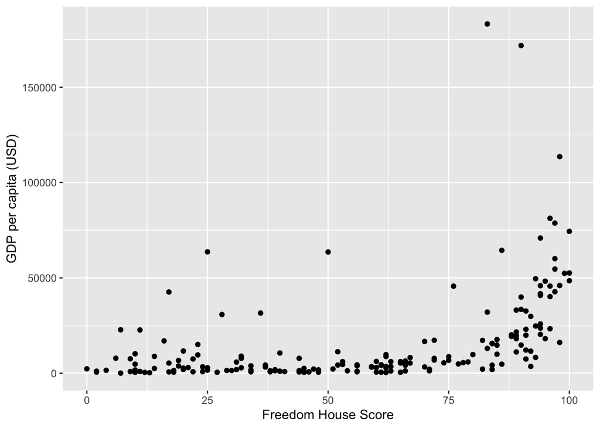

```r
Country_df %>%
  ggplot() +
  geom_point(aes(x = Freedom, y = GDP_per_capita)) +
  labs(x = "Freedom House Score", y = "GDP per capita (USD)")
```

9. 先進国と開発途上国で色分けをする。
   - `color`にマッピング

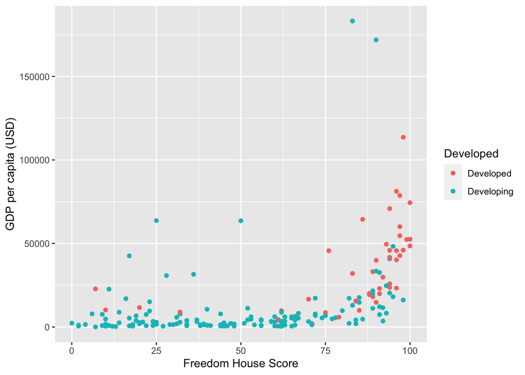

```r
Country_df %>%
  ggplot() +
  geom_point(aes(x = Freedom, y = GDP_per_capita,
                 color = Developed)) +
  labs(x = "Freedom House Score", y = "GDP per capita (USD)")
```

10. 人口に応じて異なるサイズを与える。
- `size`にマッピング

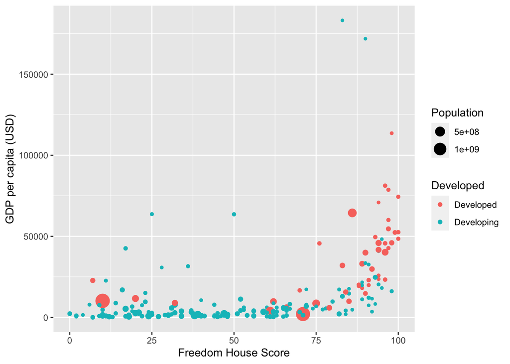

```r
Country_df %>%
  ggplot() +
  geom_point(aes(x = Freedom, y = GDP_per_capita,
                 color = Developed, size = Population)) +
  labs(x = "Freedom House Score", y = "GDP per capita (USD)")
```

11. 大陸ごとの民主主義指標の箱ひげ図を作成する。先進国と開発途上国で色分けすること。

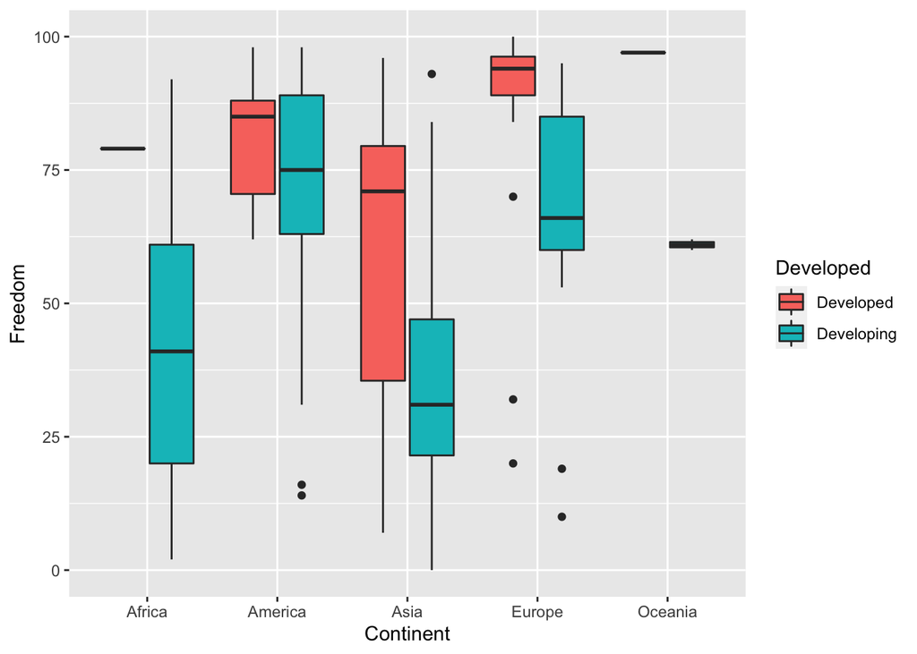

```r
Country_df %>%
  ggplot() +
  geom_boxplot(aes(x = Continent, y = Freedom, fill = Developed))
```

### 4. `COVID19_Worldwide.csv`の処理と可視化

1. `COVID_Worldwide.csv`ファイルを読み込み、`COVID_df`という名のオブジェクトに格納する。
   - `Country`: 国家名
   - 各列は当該年月日におけるCOVID-19累積感染者数を意味する。

```r
COVID_df <- read_csv("Data/COVID19_Worldwide.csv")
```

2. データの中身を確認する。

```r
COVID_df
```

```
## # A tibble: 186 x 172
##    Country `2020/1/22` `2020/1/23` `2020/1/24` `2020/1/25` `2020/1/26`
##    <chr>         <dbl>       <dbl>       <dbl>       <dbl>       <dbl>
##  1 Afghan…           0           0           0           0           0
##  2 Albania           0           0           0           0           0
##  3 Algeria           0           0           0           0           0
##  4 Andorra           0           0           0           0           0
##  5 Angola            0           0           0           0           0
##  6 Antigu…           0           0           0           0           0
##  7 Argent…           0           0           0           0           0
##  8 Armenia           0           0           0           0           0
##  9 Austra…           0           0           0           0           4
## 10 Austria           0           0           0           0           0
## # … with 176 more rows, and 166 more variables: `2020/1/27` <dbl>,
## #   `2020/1/28` <dbl>, `2020/1/29` <dbl>, `2020/1/30` <dbl>, `2020/1/31` <dbl>,
## #   `2020/2/1` <dbl>, `2020/2/2` <dbl>, `2020/2/3` <dbl>, `2020/2/4` <dbl>,
## #   `2020/2/5` <dbl>, `2020/2/6` <dbl>, `2020/2/7` <dbl>, `2020/2/8` <dbl>,
## #   `2020/2/9` <dbl>, `2020/2/10` <dbl>, `2020/2/11` <dbl>, `2020/2/12` <dbl>,
## #   `2020/2/13` <dbl>, `2020/2/14` <dbl>, `2020/2/15` <dbl>, `2020/2/16` <dbl>,
## #   `2020/2/17` <dbl>, `2020/2/18` <dbl>, `2020/2/19` <dbl>, `2020/2/20` <dbl>,
## #   `2020/2/21` <dbl>, `2020/2/22` <dbl>, `2020/2/23` <dbl>, `2020/2/24` <dbl>,
## #   `2020/2/25` <dbl>, `2020/2/26` <dbl>, `2020/2/27` <dbl>, `2020/2/28` <dbl>,
## #   `2020/2/29` <dbl>, `2020/3/1` <dbl>, `2020/3/2` <dbl>, `2020/3/3` <dbl>,
## #   `2020/3/4` <dbl>, `2020/3/5` <dbl>, `2020/3/6` <dbl>, `2020/3/7` <dbl>,
## #   `2020/3/8` <dbl>, `2020/3/9` <dbl>, `2020/3/10` <dbl>, `2020/3/11` <dbl>,
## #   `2020/3/12` <dbl>, `2020/3/13` <dbl>, `2020/3/14` <dbl>, `2020/3/15` <dbl>,
## #   `2020/3/16` <dbl>, `2020/3/17` <dbl>, `2020/3/18` <dbl>, `2020/3/19` <dbl>,
## #   `2020/3/20` <dbl>, `2020/3/21` <dbl>, `2020/3/22` <dbl>, `2020/3/23` <dbl>,
## #   `2020/3/24` <dbl>, `2020/3/25` <dbl>, `2020/3/26` <dbl>, `2020/3/27` <dbl>,
## #   `2020/3/28` <dbl>, `2020/3/29` <dbl>, `2020/3/30` <dbl>, `2020/3/31` <dbl>,
## #   `2020/4/1` <dbl>, `2020/4/2` <dbl>, `2020/4/3` <dbl>, `2020/4/4` <dbl>,
## #   `2020/4/5` <dbl>, `2020/4/6` <dbl>, `2020/4/7` <dbl>, `2020/4/8` <dbl>,
## #   `2020/4/9` <dbl>, `2020/4/10` <dbl>, `2020/4/11` <dbl>, `2020/4/12` <dbl>,
## #   `2020/4/13` <dbl>, `2020/4/14` <dbl>, `2020/4/15` <dbl>, `2020/4/16` <dbl>,
## #   `2020/4/17` <dbl>, `2020/4/18` <dbl>, `2020/4/19` <dbl>, `2020/4/20` <dbl>,
## #   `2020/4/21` <dbl>, `2020/4/22` <dbl>, `2020/4/23` <dbl>, `2020/4/24` <dbl>,
## #   `2020/4/25` <dbl>, `2020/4/26` <dbl>, `2020/4/27` <dbl>, `2020/4/28` <dbl>,
## #   `2020/4/29` <dbl>, `2020/4/30` <dbl>, `2020/5/1` <dbl>, `2020/5/2` <dbl>,
## #   `2020/5/3` <dbl>, `2020/5/4` <dbl>, `2020/5/5` <dbl>, …
```

```r
COVID_df <- COVID_df %>%
  pivot_longer(cols      = "2020/1/22":"2020/7/10",
               names_to  = "Date",
               values_to = "Confirmed")
```

4. `Date`変数をDate型へ変換する。

```r
COVID_df <- COVID_df %>%
  mutate(Date = as.Date(Date))
```

5. データから日本（`"Japan"`）、韓国（`"South Korea"`）、シンガポール（`"Singapore"`）、スイス（`"Switzerland"`）のみを抽出する。抽出したデータは`COVID_df2`という名のオブジェクトとして格納する。

```r
COVID_df2 <- COVID_df %>%
  filter(Country %in% c("Japan", "South Korea", "Singapore", "Switzerland"))
```

6. 変換後のデータを確認する。

```r
COVID_df2
```

```
## # A tibble: 684 x 3
##    Country Date       Confirmed
##    <chr>   <date>         <dbl>
##  1 Japan   2020-01-22         2
##  2 Japan   2020-01-23         2
##  3 Japan   2020-01-24         2
##  4 Japan   2020-01-25         2
##  5 Japan   2020-01-26         4
##  6 Japan   2020-01-27         4
##  7 Japan   2020-01-28         7
##  8 Japan   2020-01-29         7
##  9 Japan   2020-01-30        11
## 10 Japan   2020-01-31        15
## # … with 674 more rows
```

7. 横軸を年月日、縦軸を累積感染者数とした折れ線グラフを作成する。国ごとに異なる色を付ける。

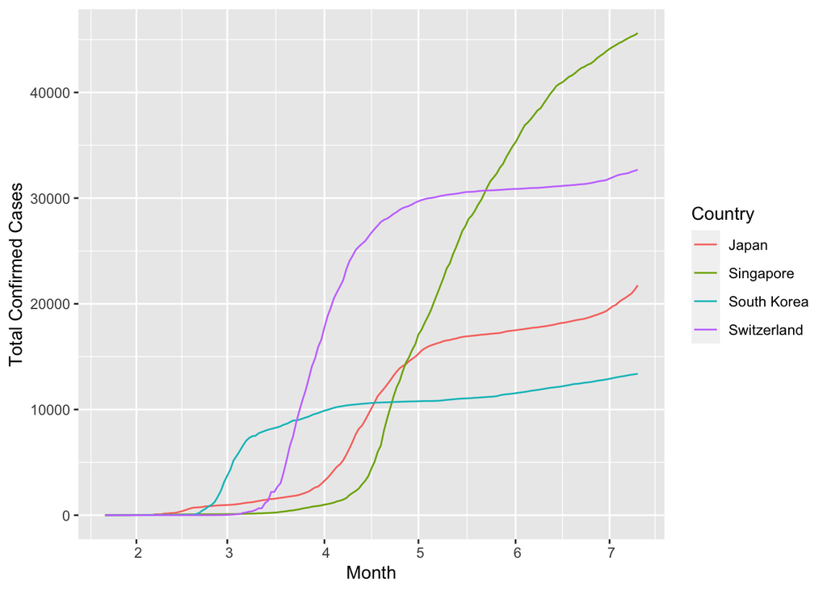

```r
COVID_df2 %>%
  ggplot() +
  geom_line(aes(x = Date, y = Confirmed, color = Country)) +
  labs(x = "Month", y = "Total Confirmed Cases")
```

8. `COVID_df`から（`COVID_df2`ではない）年月日が2020年7月10日（`"2020-07-10"`）である行のみ抽出し、`Date`列を除外する。結果を`COVID_df3`という名のオブジェクトとして格納する。

```r
COVID_df3 <- COVID_df %>%
  filter(Date == "2020-07-10") %>%
  select(-Date)
```

9. `COVID_df3`を累積感染者数が多い順でソートする。

```r
COVID_df3 %>%
  arrange(desc(Confirmed))
```

```
## # A tibble: 186 x 2
##    Country        Confirmed
##    <chr>              <dbl>
##  1 United States    3184582
##  2 Brazil           1800827
##  3 India             820916
##  4 Russia            712863
##  5 Peru              319646
##  6 Chile             309274
##  7 United Kingdom    289678
##  8 Mexico            289174
##  9 Spain             253908
## 10 Iran              252720
## # … with 176 more rows
```

10. `Country_df`と`COVID_df3`を結合する。キーは`"Country"`である。`Country_df`に合わせて結合すること。

```r
Country_df <- left_join(Country_df, COVID_df3, by = "Country")
```

11. `Country_df`の中身を確認する。

```r
names(Country_df)
```

```
##  [1] "Country"        "Population"     "Area"           "Density"
##  [5] "GDP"            "GDP_per_capita" "Continent"      "HDI"
##  [9] "Life"           "Education"      "Freedom"        "Developed"
## [13] "Confirmed"
```

12. 人口100万人当たり感染者数を計算し、`Confirmed2`という列としてデータに追加する。

$$100万人当たり感染者数 = \frac{累積感染者数 \times 1000000}{人口}.$$

```r
Country_df <- Country_df %>%
  mutate(Confirmed2 = Confirmed / Population * 1000000)
```

13. 横軸は人口密度、縦軸は100万人当たり累積感染者数を示した散布図を作成する。

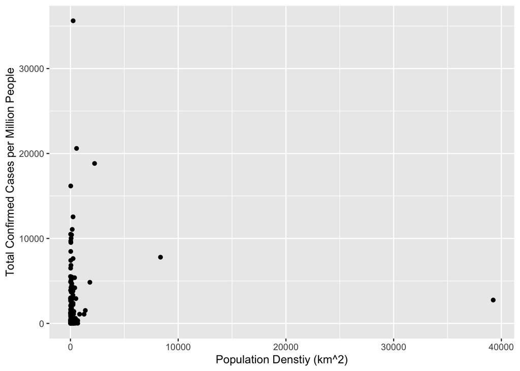

```r
Country_df %>%
  ggplot() +
  geom_point(aes(x = Density, y = Confirmed2)) +
  labs(x = "Population Denstiy (km^2)",
       y = "Total Confirmed Cases per Million People")
```

14. `dplyr::filter()`を利用して`Density`が5000未満のみを抽出し、同じグラフを出力する。

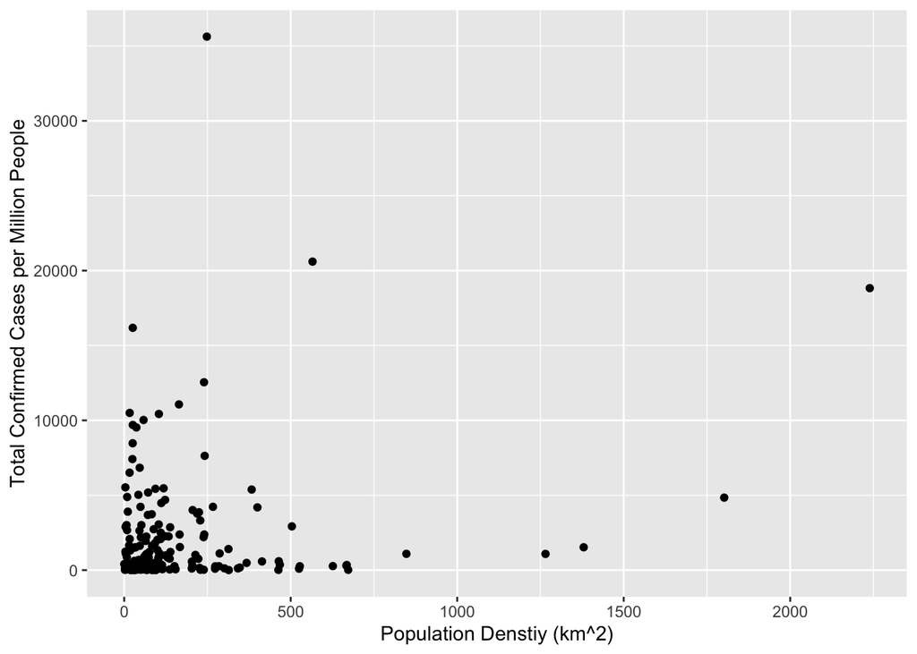

```r
Country_df %>%
  filter(Density < 5000) %>%
  ggplot() +
  geom_point(aes(x = Density, y = Confirmed2)) +
  labs(x = "Population Denstiy (km^2)",
       y = "Total Confirmed Cases per Million People")
```

15. 大陸がオセアニア（`"Oceania"`）の国を除外し、大陸ごとの民主主義指標と100万人当たり感染者数の関係を散布図で示す。

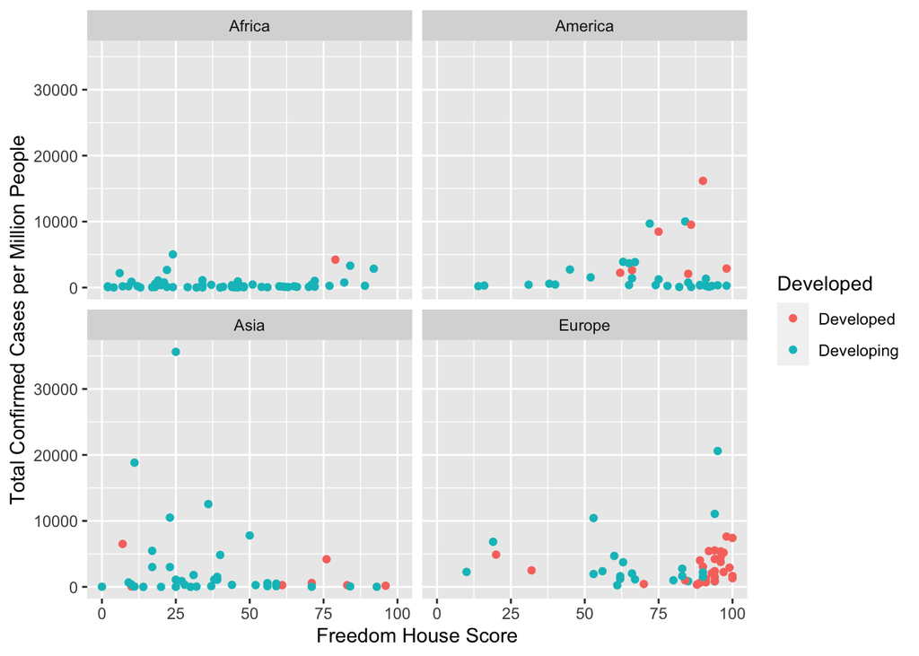

```r
Country_df %>%
  filter(Continent != "Oceania") %>%
  ggplot() +
  geom_point(aes(x = Freedom, y = Confirmed2, color = Developed)) +
  facet_wrap(~ Continent) +
  labs(x = "Freedom House Score",
       y = "Total Confirmed Cases per Million People")
```

16. これまで作業した`Country_df`を`Data_xxxxxxxxx.csv`という名でパソコンに保存する。`xxxxxxxxx`は自分の学籍番号にする。

```r
write_csv(Country_df, "Data/Data_123456789.csv")
```